# **HANDWRITTEN TEXT RECOGNITION USING CNN + RNN**

In this notebook, we will train a Convoluted Neural Network (CNN) model to recognize handwritting by training our model on handwrittings of names and RNN for character processing. The dataset comes in two forms: image (jpg) file along with the written name (csv) file which can be read with pandas.

As always, we start by loading Python packages.

## Loading Python Libraries

```python
import numpy as np
import pandas as pd
import cv2
import matplotlib.pyplot as plt
import warnings
warnings.filterwarnings("ignore")
%matplotlib inline
from IPython.display import Image
from sklearn.model_selection import train_test_split
import tensorflow as tf
from keras import backend as K
from keras.models import Model
from keras.layers import Input, Conv2D, MaxPooling2D, Reshape, Bidirectional, LSTM, Dense, Lambda, Activation, BatchNormalization, Dropout
from tensorflow.keras.optimizers import Adam
```

```python
# check for gpu availability
print ("GPU", " available" if tf.config.list_physical_devices("GPU") else ("not available"))
```

```
GPU  available
```

## **Loading, Viewing and Making Sense of Dataset**

We will now load the datasets, consisting of image files and the csv files. The datasets has been conveniently separated into train, validation and test sets. we are laoding the validation set as our complete dataset which consists of 40k+ images..

- It is in the form of zip file so we need to unzip the data first.
- The csv file containing imagename and label is then loaded..

```python
#!unzip "/content/drive/MyDrive/soumya/final project/validation_v2.zip" -d "/content/drive/MyDrive/soumya/final project/"
```

```python
df = pd.read_csv("drive/MyDrive/soumya/final project/written_name_validation_v2.csv")
```

### Exploratory Data Analysis on csv file..

```python
display(df.head())
```

|  | FILENAME | IDENTITY |
| --- | --- | --- |
| 0 | VALIDATION_0001.jpg | BILEL |
| 1 | VALIDATION_0002.jpg | LAUMIONIER |
| 2 | VALIDATION_0003.jpg | LEA |
| 3 | VALIDATION_0004.jpg | JEAN-ROCH |
| 4 | VALIDATION_0005.jpg | RUPP |

```python
df.columns
```

```
Index(['FILENAME', 'IDENTITY'], dtype='object')
```

```python
df.info()
```

```
<class 'pandas.core.frame.DataFrame'>
RangeIndex: 41370 entries, 0 to 41369
Data columns (total 2 columns):
 #   Column    Non-Null Count  Dtype
---  ------    --------------  -----
 0   FILENAME  41370 non-null  object
 1   IDENTITY  41292 non-null  object
dtypes: object(2)
memory usage: 646.5+ KB
```

```python
df.describe()
```

|  | FILENAME | IDENTITY |
| --- | --- | --- |
| count | 41370 | 41292 |
| unique | 41370 | 20227 |
| top | VALIDATION_0001.jpg | THOMAS |
| freq | 1 | 219 |

Let's visualize some images in our data

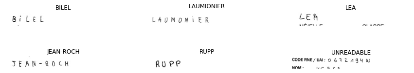

```python
plt.figure(figsize=(15,10))

for i in range(6):
    ax = plt.subplot(2, 3, i+1)
    img_dir = 'drive/MyDrive/soumya/final project/validation/'+df.loc[i, 'FILENAME']
    image = cv2.imread(img_dir, cv2.IMREAD_GRAYSCALE)
    plt.imshow(image, cmap = 'gray')
    plt.title(df.loc[i, 'IDENTITY'], fontsize=12)
    plt.axis('off')

plt.subplots_adjust(wspace=0.2, hspace=-0.8)
```

We can check the distribution of labels using visualization. Lets check which name image is more in the data ..

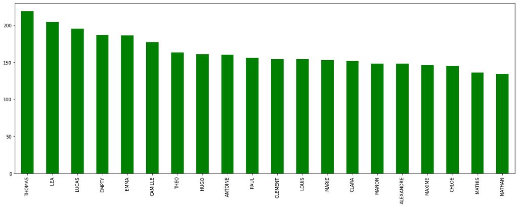

```python
val_counts = df["IDENTITY"].value_counts()
plt.figure(figsize = (20,7))
val_counts[:20].plot(kind='bar', color = "green")
plt.show()
```

It is evident that the data have more images of the name `THOMAS` about 220 then `LEA` almost 200 and then `LUCAS`

### Data Cleaning

Null Value Treatment

```python
print("Number of NaNs in the dataset is: ", df['IDENTITY'].isnull().sum())
```

```
Number of NaNs in the dataset is:  78
```

```python
df = df.dropna(axis = 0)
print("Number of NaNs in the dataset is: ", df['IDENTITY'].isnull().sum())
```

```
Number of NaNs in the dataset is:  0
```

We removed the missing values. Now we look at the dimensions..

```python
df.shape
```

```
(41292, 2)
```

The data contains many images which was not identifiable and those images are labelled as `UNREADABLE` and `EMPTY`. We are removing those categories from our data. First we can look at those images...

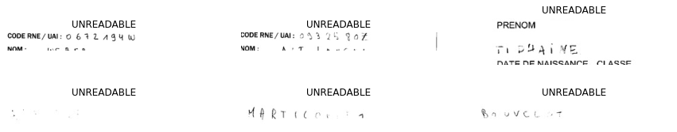

```python
unreadable = df[df['IDENTITY'] == 'UNREADABLE']
unreadable.reset_index(inplace = True, drop = True)

plt.figure(figsize=(15,10))

for i in range(6):
    ax = plt.subplot(2, 3, i+1)
    img_dir = 'drive/MyDrive/soumya/final project/validation/'+unreadable.loc[i, 'FILENAME']
    image = cv2.imread(img_dir, cv2.IMREAD_GRAYSCALE)
    plt.imshow(image, cmap = 'gray')
    plt.title(unreadable.loc[i, 'IDENTITY'], fontsize=12)
    plt.axis('off')

plt.subplots_adjust(wspace=0.2, hspace=-0.8)
```

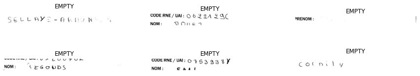

```python
empty = df[df['IDENTITY'] == 'EMPTY']
empty.reset_index(inplace = True, drop = True)

plt.figure(figsize=(15,10))

for i in range(6):
    ax = plt.subplot(2, 3, i+1)
    img_dir = 'drive/MyDrive/soumya/final project/validation/'+empty.loc[i, 'FILENAME']
    image = cv2.imread(img_dir, cv2.IMREAD_GRAYSCALE)
    plt.imshow(image, cmap = 'gray')
    plt.title(empty.loc[i, 'IDENTITY'], fontsize=12)
    plt.axis('off')

plt.subplots_adjust(wspace=0.2, hspace=-0.8)
```

```python
unreadable.shape, empty.shape
```

```
((12, 2), (187, 2))
```

Now we drop unreadable images in the csv dataset

```python
df = df[df["IDENTITY"] != "UNREADABLE"]
df = df[df["IDENTITY"] != "EMPTY"]
df.shape
```

```
(41093, 2)
```

Setting all labels to uppercases for uniformity in data.

```python
df['IDENTITY'] = df['IDENTITY'].str.upper()
```

```
 Median :  1.0
```

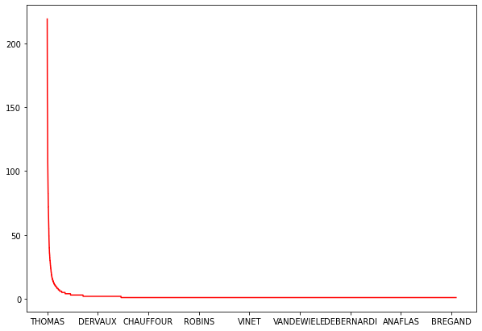

```python
print(" Median : ", df["IDENTITY"].value_counts().median())
plt.figure(figsize = (10,7))
val_counts.plot(color = "red")
plt.show()
```

By looking at the median value we can say that there are labels with only one image. For better recognition we choose to have atleat 4 images for one label.

```python
df = df.groupby('IDENTITY').filter(lambda x : len(x)>3)
df.describe()
```

|  | FILENAME | IDENTITY |
| --- | --- | --- |
| count | 18904 | 18904 |
| unique | 18904 | 1151 |
| top | VALIDATION_0003.jpg | THOMAS |
| freq | 1 | 219 |

```
 Median :  7.0
```

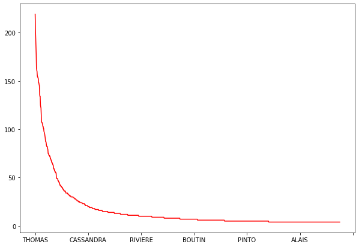

```python
print(" Median : ", df["IDENTITY"].value_counts().median())
plt.figure(figsize = (10,7))
df["IDENTITY"].value_counts().plot(color = "red")
plt.show()
```

```python
df.shape
```

```
(18904, 2)
```

Now we have 18904 samples with atleast 4 images for a label..

Now we reset the index and the cleaning process is done

```python
df.reset_index(inplace = True, drop = True)
display(df.head(10))
print(df.shape)
```

|  | FILENAME | IDENTITY |
| --- | --- | --- |
| 0 | VALIDATION_0003.jpg | LEA |
| 1 | VALIDATION_0008.jpg | DANIEL |
| 2 | VALIDATION_0009.jpg | JEREMY |
| 3 | VALIDATION_0011.jpg | JULIEN |
| 4 | VALIDATION_0012.jpg | NAEL |
| 5 | VALIDATION_0014.jpg | TIFFANY |
| 6 | VALIDATION_0016.jpg | ANTOINE |
| 7 | VALIDATION_0017.jpg | AYOUB |
| 8 | VALIDATION_0020.jpg | CELESTIN |
| 9 | VALIDATION_0022.jpg | MATHIS |

```
(18904, 2)
```

Let's check whether the image with the given filename has same image as Identity..

```python
Image("drive/MyDrive/soumya/final project/validation/VALIDATION_0014.jpg")
```

[output not shown]

## **Image Preprocessing**

```python
def image_processing(img):
    (h, w) = img.shape

    final_img = np.ones([64, 256])*255 # blank white image

    # crop if image dimension exceeds the said criteria
    if w > 256:
        img = img[:, :256]
    if h > 64:
        img = img[:64, :]

    final_img[:h, :w] = img
    return cv2.rotate(final_img, cv2.ROTATE_90_CLOCKWISE)
```

```python
size = df.shape[0]
x = []
for i in range(size):
    img_dir = 'drive/MyDrive/soumya/final project/validation/' + df.loc[i, 'FILENAME']
    image = cv2.imread(img_dir, cv2.IMREAD_GRAYSCALE)
    image = image_processing(image)
    image = image/255.
    x.append(image)
```

```python
# Setup X & y variables
x = np.asarray(x)
y = df["IDENTITY"].to_numpy()
len(x),len(y)
```

```
(18904, 18904)
```

```python
y
```

```
array(['LEA', 'DANIEL', 'JEREMY', ..., 'SHANA', 'MAXENCE', 'LOLA'],
      dtype=object)
```

Now we have our feature data and labels we need to split them

```python
x_train,x_test,y_train,y_test = train_test_split(x,y,test_size = 0.2,random_state = 42)
```

```python
x_train = np.array(x_train).reshape(-1, 256, 64, 1)
```

```python
x_test =np.array(x_test).reshape(-1, 256, 64, 1)
```

## **Character processing**

We will now process the strings of names by converting them into numbers via a systematic sets of rules (CTC loss) for text recognition. The alphabets contain A-Z and three special characters (- ' and space).

```python
alphabets = u"ABCDEFGHIJKLMNOPQRSTUVWXYZ-' "
max_str_len = 24 # max length of input name
num_characters = len(alphabets) + 1 # the plus one is to account for ctc pseudo blank
num_of_timestamps = 64 # max length of predicted names

def name_to_num(name):
    name_num = []
    for ch in name:
        name_num.append(alphabets.find(ch))
    return np.array(name_num)

def num_to_name(num):
    name = ""
    for ch in num:
        if ch == -1: # CTC blank
            break
        else:
            name += alphabets[ch]
    return name
```

Here we will create 4 variables for each of the sets (train, test). For instance:

- **train_y** contains the true numerical representation of name and padded with -1. The length is equal to max_str_len.
- **train_name_len** is the length of name without padding.
- **train_input_len** is the length of each predicted name. The length of all the predicted names is constant and is (num_of_timestamps - 2).
- **train_output** is the output for the ML model.

```python
train_size = x_train.shape[0]
test_size = x_test.shape[0]


train_y = np.ones([train_size, max_str_len]) * -1
train_name_len = np.zeros([train_size, 1])
train_input_len = np.ones([train_size, 1]) * (num_of_timestamps-2)
train_output = np.zeros([train_size])

for i in range(train_size):
    train_name_len[i] = len(y_train[i])
    train_y[i, 0:len(y_train[i])] = name_to_num(y_train[i])

test_y = np.ones([test_size, max_str_len]) * -1
test_name_len = np.zeros([test_size, 1])
test_input_len = np.ones([test_size, 1]) * (num_of_timestamps-2)
test_output = np.zeros([test_size])

for i in range(test_size):
    test_name_len[i] = len(y_test[i])
    test_y[i, 0:len(y_test[i])]= name_to_num(y_test[i])
```

## **Building our hybrid CNN + RNN model**

We are now ready to build our machine learning model.

- We will use CNN to process images (as our x variable) and connect it to RNN (to process our y variable, i.e., names and characters).
- We will employ deep CNN architecture (3 layers) and shallow RNN architecture (2 layers).
- We will also define a CTC loss function beforehand.

```python
def ctc_lambda_func(args):
    y_pred, names, input_length, name_length = args

    y_pred = y_pred[:, 2:, :]
    return K.ctc_batch_cost(names, y_pred, input_length, name_length)

input_data = Input(shape=(256, 64, 1), name='input')

# CNN
inner = Conv2D(32, (3, 3), padding='same', name='conv1', kernel_initializer='he_normal')(input_data)
inner = BatchNormalization()(inner)
inner = Activation('relu')(inner)
inner = MaxPooling2D(pool_size=(2,2), name='max1')(inner)

inner = Conv2D(64, (3, 3), padding='same', name='conv2', kernel_initializer='he_normal')(inner)
inner = BatchNormalization()(inner)
inner = Activation('relu')(inner)
inner = MaxPooling2D(pool_size=(2,2), name='max2')(inner)
inner = Dropout(0.3)(inner)

inner = Conv2D(128, (3, 3), padding='same', name='conv3', kernel_initializer='he_normal')(inner)
inner = BatchNormalization()(inner)
inner = Activation('relu')(inner)
inner = MaxPooling2D(pool_size=(1,2), name='max3')(inner)
inner = Dropout(0.3)(inner)

# CNN to RNN
inner = Reshape(target_shape = ((64, 1024)), name='reshape')(inner)
inner = Dense(64, activation='relu', kernel_initializer='he_normal', name='dense1')(inner)

# RNN
inner = Bidirectional(LSTM(256, return_sequences=True), name='lstm1')(inner)
inner = Bidirectional(LSTM(256, return_sequences=True), name='lstm2')(inner)

# Output
inner = Dense(num_characters, kernel_initializer='he_normal', name='dense2')(inner)
y_pred = Activation('softmax', name='softmax')(inner)

model = Model(inputs=input_data, outputs=y_pred)

# Now include the ctc loss function and compile
names = Input(name='gtruth_names', shape=[max_str_len], dtype='float32')
input_length = Input(name='input_length', shape=[1], dtype='int64')
name_length = Input(name='name_length', shape=[1], dtype='int64')
ctc_loss = Lambda(ctc_lambda_func, output_shape=(1,), name='ctc')([y_pred, names, input_length, name_length])

model_final = Model(inputs=[input_data, names, input_length, name_length], outputs=ctc_loss)
model_final.compile(loss={'ctc': lambda y_true, y_pred: y_pred}, optimizer=Adam(lr=0.0001))
```

```python
model.summary()
```

```
Model: "model"
_________________________________________________________________
 Layer (type)                Output Shape              Param #
=================================================================
 input (InputLayer)          [(None, 256, 64, 1)]      0

 conv1 (Conv2D)              (None, 256, 64, 32)       320

 batch_normalization (BatchN  (None, 256, 64, 32)      128
 ormalization)

 activation (Activation)     (None, 256, 64, 32)       0

 max1 (MaxPooling2D)         (None, 128, 32, 32)       0

 conv2 (Conv2D)              (None, 128, 32, 64)       18496

 batch_normalization_1 (Batc  (None, 128, 32, 64)      256
 hNormalization)

 activation_1 (Activation)   (None, 128, 32, 64)       0

 max2 (MaxPooling2D)         (None, 64, 16, 64)        0

 dropout (Dropout)           (None, 64, 16, 64)        0

 conv3 (Conv2D)              (None, 64, 16, 128)       73856

 batch_normalization_2 (Batc  (None, 64, 16, 128)      512
 hNormalization)

 activation_2 (Activation)   (None, 64, 16, 128)       0

 max3 (MaxPooling2D)         (None, 64, 8, 128)        0

 dropout_1 (Dropout)         (None, 64, 8, 128)        0

 reshape (Reshape)           (None, 64, 1024)          0

 dense1 (Dense)              (None, 64, 64)            65600

 lstm1 (Bidirectional)       (None, 64, 512)           657408

 lstm2 (Bidirectional)       (None, 64, 512)           1574912

 dense2 (Dense)              (None, 64, 30)            15390

 softmax (Activation)        (None, 64, 30)            0

=================================================================
Total params: 2,406,878
Trainable params: 2,406,430
Non-trainable params: 448
_________________________________________________________________
```

## Training our model

We are now ready to train our model.

```python
model_final.fit(x=[x_train, train_y, train_input_len, train_name_len], y=train_output,
                validation_data=([x_test, test_y, test_input_len, test_name_len], test_output),
                epochs=60, batch_size=128)
```

```
<keras.callbacks.History at 0x7ff0cf28d7f0>
```

## Performance on the test dataset

We will now use our trained model on the test dataset to measure the accuracy of our model.

```python
preds = model.predict(x_test)
decoded = K.get_value(K.ctc_decode(preds, input_length=np.ones(preds.shape[0])*preds.shape[1],
                                   greedy=True)[0][0])

prediction = []
for i in range(test_size):
    prediction.append(num_to_name(decoded[i]))
```

```python
y_test[:10]
```

```
array(['PAULINE', 'LEGRAND', 'MATHIS', 'NOAH', 'RAFAEL', 'ALEXANDRE',
       'CELIA', 'AYOUB', 'ARTHUR', 'DOUNIA'], dtype=object)
```

```python
prediction[:10]
```

```
['PAUINE',
 'LEAND',
 'MATHIS',
 'NOAH',
 'MRAMEL',
 'VALXANDRE',
 'CELIA',
 'MAUUD',
 'MARTHUR',
 'JDUNIA']
```

```python
y_true = y_test[0:test_size]
correct_char = 0
total_char = 0
correct = 0

for i in range(test_size):
    pr = prediction[i]
    tr = y_true[i]
    total_char += len(tr)

    for j in range(min(len(tr), len(pr))):
        if tr[j] == pr[j]:
            correct_char += 1

    if pr == tr :
        correct += 1

print('Correct characters predicted : %.2f%%' %(correct_char*100/total_char))
print('Correct words predicted      : %.2f%%' %(correct*100/test_size))
```

```
Correct characters predicted : 56.22%
Correct words predicted      : 37.37%
```

## Prediction Using Outside Data

```python
df = pd.read_csv("drive/MyDrive/soumya/final project/written_name_test_v2.csv")
display(df.head())
```

|  | FILENAME | IDENTITY |
| --- | --- | --- |
| 0 | TEST_0001.jpg | KEVIN |
| 1 | TEST_0002.jpg | CLOTAIRE |
| 2 | TEST_0003.jpg | LENA |
| 3 | TEST_0004.jpg | JULES |
| 4 | TEST_0005.jpg | CHERPIN |

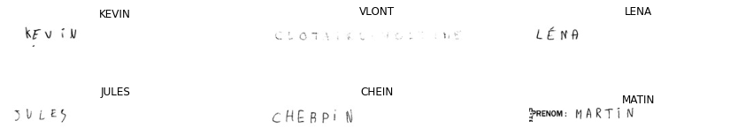

```python
plt.figure(figsize=(15,10))

for i in range(6):
    ax = plt.subplot(2, 3, i+1)
    img_dir = 'drive/MyDrive/soumya/final project/test/' + df.loc[i, 'FILENAME']
    image = cv2.imread(img_dir, cv2.IMREAD_GRAYSCALE)
    plt.imshow(image, cmap = 'gray')

    image = image_processing(image)
    image = image/255.
    pred = model.predict(image.reshape(1, 256, 64, 1))
    decoded = K.get_value(K.ctc_decode(pred, input_length = np.ones(pred.shape[0])*pred.shape[1], greedy=True)[0][0])
    plt.title(num_to_name(decoded[0]), fontsize=12)
    plt.axis('off')

plt.subplots_adjust(wspace=0.2, hspace=-0.8)
```

## **Remarks**

The accurracy of the model can be increased by adding more training samples....